# p8451_assignment_6

2023-02-27

## Part 0: Data Cleaning

### Loading packages and preparing dataset

To proceed with the problem set, the following libraries will be used in addition to base R

```r
library(tidyverse)
library(rpart)
library(caret)
```

```r
library(rpart.plot)
library(pROC)
library(dplyr)
library(NHANES)
library(e1071)

set.seed(123)
```

The NHANES dataset from 1999-2004 is first imported and restricted to the list of 11 variables below:

- Age
- Race1
- Education
- HHIncome
- Weight
- Height
- Pulse
- Diabetes
- BMI
- Phys Active
- Smoke100

The data set is then cleaned using the `clean_names` function and summarised using the `skim` function. Missing variables were omitted using the `na.omit` function. The reference input for the outcome variable `diabetes` is changed to “Yes”.

```r
data("NHANES")

nhanes = NHANES %>%
         select("Age", "Race1", "Education", "HHIncome", "Weight", "Height", "Pulse", "Diabetes", "BMI", "PhysActive", "Smoke100") %>%
         janitor::clean_names() %>%
         na.omit()

nhanes$diabetes = relevel(nhanes$diabetes, ref = "Yes")

skimr::skim(nhanes)
```

Data summary

| Name | nhanes |
| --- | --- |
| Number of rows | 6356 |
| Number of columns | 11 |
| _______________________ |  |
| Column type frequency: |  |
| factor | 6 |
| numeric | 5 |
| ________________________ |  |
| Group variables | None |

**Variable type: factor**

| skim_variable | n_missing | complete_rate | ordered | n_unique | top_counts |
| --- | --- | --- | --- | --- | --- |
| race1 | 0 | 1 | FALSE | 5 | Whi: 4391, Bla: 676, Mex: 492, Oth: 450 |
| education | 0 | 1 | FALSE | 5 | Som: 1991, Col: 1917, Hig: 1333, 9 -: 764 |
| hh_income | 0 | 1 | FALSE | 12 | mor: 1553, 750: 770, 250: 660, 350: 605 |
| diabetes | 0 | 1 | FALSE | 2 | No: 5697, Yes: 659 |
| phys_active | 0 | 1 | FALSE | 2 | Yes: 3422, No: 2934 |
| smoke100 | 0 | 1 | FALSE | 2 | No: 3544, Yes: 2812 |

**Variable type: numeric**

| skim_variable | n_missing | complete_rate | mean | sd | p0 | p25 | p50 | p75 | p100 | hist |
| --- | --- | --- | --- | --- | --- | --- | --- | --- | --- | --- |
| age | 0 | 1 | 47.12 | 16.82 | 20.00 | 33.00 | 46.0 | 60.00 | 80.00 | ▇▇▇▆▅ |
| weight | 0 | 1 | 82.88 | 21.37 | 37.00 | 67.60 | 80.0 | 94.80 | 230.70 | ▆▇▁▁▁ |
| height | 0 | 1 | 169.14 | 10.04 | 139.90 | 161.90 | 169.2 | 176.20 | 200.40 | ▁▆▇▅▁ |
| pulse | 0 | 1 | 72.41 | 11.81 | 40.00 | 64.00 | 72.0 | 80.00 | 128.00 | ▁▇▅▁▁ |
| bmi | 0 | 1 | 28.88 | 6.71 | 15.02 | 24.15 | 27.8 | 32.35 | 81.25 | ▇▆▁▁▁ |

```r
summary(nhanes$diabetes)
```

```
##  Yes   No
##  659 5697
```

The data set is comprised of 6,356 observations of 11 variables, 5 of which are numeric (`age`, `weight`, `height`, `pulse`, and `bmi`) and 6 of which are factor variables (`race1`, `education`, `hh_income`, `diabetes`, `phys_active`, and `smoke100`).

## Creating balanced partitions in the datta

The data is then partitioned into training and testing data sets using a 70/30 split through the function `createDataPartition`. The training and testing data set is generated with an equal proportion of individuals with the outcome of interest, `diabetes`.

```r
set.seed(123)

train_indices =
  createDataPartition(y = nhanes$diabetes, p = 0.7, list = FALSE)

nhanes_train = nhanes[train_indices,]
nhanes_test = nhanes[-train_indices,]
```

## Part 1: Creating and comparing three different models

The following three models will be created and compared to generate an optimal model for predicting diabetes:

- Classification tree
- Support vector classifier
- Logistic regression

### Classification tree

When creating the classification tree, we first create our control settings using `trainControl`. We specify a 10-fold cross-validation and use down-sampling in our control settings, as the outcome of interest, `diabetes` is unbalanced. We then create a sequence of complexity parameters to try. The train model is created using the `train` function and `rpart` method. The best tune is then displayed, along with the confusion matrix for this classification tree.

```r
set.seed(123)

nhanes_train_control = trainControl(method = "cv", number = 10, sampling = "down")

grid = expand.grid(cp = seq(0.001, 0.3, by = 0.01))

tree_diabetes = train(diabetes~.,
                      data = nhanes_train,
                      method = "rpart",
                      trControl = nhanes_train_control,
                      tuneGrid = grid)

tree_diabetes$bestTune
```

```
##      cp
## 1 0.001
```

```r
confusionMatrix(tree_diabetes)
```

```
## Cross-Validated (10 fold) Confusion Matrix
##
## (entries are percentual average cell counts across resamples)
##
##           Reference
## Prediction  Yes   No
##        Yes  7.6 25.4
##        No   2.8 64.2
##
##  Accuracy (average) : 0.718
```

The accuracy value for the classification tree model from the training data set is 0.718 with a cp value of 0.001

The classification tree from the training data is displayed below using the selected hyperparameters and the function `rpart.plot`.

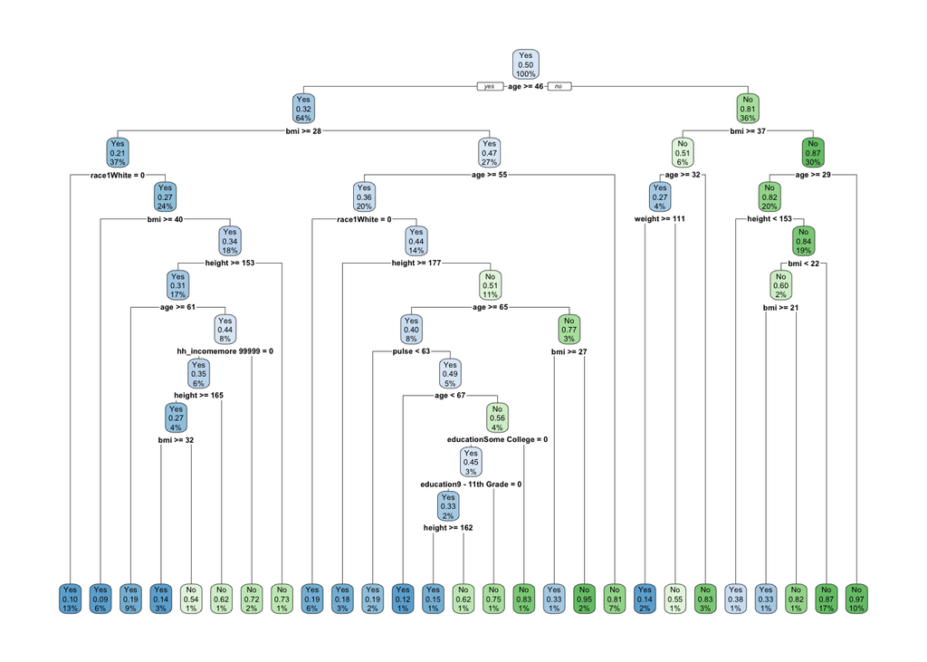

```r
rpart.plot(tree_diabetes$finalModel)
```

### Support vector classifier

When creating the support vector classifier, we first create our control settings using `trainControl`. We specify a 10-fold cross-validation and specify that `classProbs = T` to specify that we want the ability to calculate the probabilities for the training portion. Because support vector classifier goes based on distance, we center and scale the data within the `train` function. The final model is displayed, along with the confusion matrix for this support vector classifier.

```r
set.seed(123)

nhanes_train_control_svm = trainControl(method = "cv", number = 10, classProbs = T)

svm_caret = train(diabetes ~.,
                  data = nhanes_train,
                  method = "svmLinear",
                  trControl = nhanes_train_control_svm,
                  preProcess = c("center", "scale"),
                  tuneGrid = expand.grid(C = seq(0.001, 2, length = 30)))
```

[output not shown]

```r
svm_caret$finalModel
```

```
## Support Vector Machine object of class "ksvm"
##
## SV type: C-svc  (classification)
##  parameter : cost C = 0.001
##
## Linear (vanilla) kernel function.
##
## Number of Support Vectors : 1012
##
## Objective Function Value : -0.924
## Training error : 0.10382
## Probability model included.
```

```r
confusionMatrix(svm_caret)
```

```
## Cross-Validated (10 fold) Confusion Matrix
##
## (entries are percentual average cell counts across resamples)
##
##           Reference
## Prediction  Yes   No
##        Yes  0.0  0.0
##        No  10.4 89.6
##
##  Accuracy (average) : 0.8962
```

The accuracy value for the support vector classifier model from the training data set is 0.8962 and the C value is 0.001.

### Logistic regression

When conducting a logistic regression model, the training data set is fed into the `train` function with the specified method of `glm`. We specify a 10-fold cross validation and center and scale the data. The final model is displayed, along with the confusion matrix for this logistic regression model.

```r
set.seed(123)
nhanes_train_lr = train(diabetes ~.,
                        data = nhanes_train,
                        method = "glm",
                        trControl = trainControl("cv", number = 10),
                        preProcess = c("center", "scale"))

nhanes_train_lr$results
```

```
##   parameter  Accuracy     Kappa  AccuracySD    KappaSD
## 1      none 0.8952802 0.1285642 0.003404905 0.02407994
```

```r
confusionMatrix(nhanes_train_lr)
```

```
## Cross-Validated (10 fold) Confusion Matrix
##
## (entries are percentual average cell counts across resamples)
##
##           Reference
## Prediction  Yes   No
##        Yes  1.0  1.1
##        No   9.4 88.5
##
##  Accuracy (average) : 0.8953
```

The accuracy value for the logistic regression model from the training data set is 0.8953.

### Comparing models

The following accuracy values were obtained from the training data set for the three models:

- Classification Tree: 0.718
- Support Vector Classifier: 0.8962
- Logistic Regression: 0.8953

Since the support vector classifier model resulted in the highest accuracy value among the three prediction models, we can conclude that the support vector classifier is the optimal model.

## Part 2: The optimal model - support vector classifier

The support vector classifier model is used to feed into the testing data sett through the `predict` function and the final evaluation metrics are determined through generating a confusion matrix.

```r
set.seed(123)

svm_pred_test = predict(svm_caret, nhanes_test)

confusionMatrix(svm_pred_test, nhanes_test$diabetes)
```

```
## Confusion Matrix and Statistics
##
##           Reference
## Prediction  Yes   No
##        Yes    0    0
##        No   197 1709
##
##                Accuracy : 0.8966
##                  95% CI : (0.8821, 0.91)
##     No Information Rate : 0.8966
##     P-Value [Acc > NIR] : 0.519
##
##                   Kappa : 0
##
##  Mcnemar's Test P-Value : <2e-16
##
##             Sensitivity : 0.0000
##             Specificity : 1.0000
##          Pos Pred Value :    NaN
##          Neg Pred Value : 0.8966
##              Prevalence : 0.1034
##          Detection Rate : 0.0000
##    Detection Prevalence : 0.0000
##       Balanced Accuracy : 0.5000
##
##        'Positive' Class : Yes
##
```

## Part 3: Limitations and considerations

One major limitation to support vector classifier models is that it is not suitable for large data sets. SVM underperforms in cases where the number of features for each data point exceeds the number of training data samples. This also results in a large amount of time to train the datasets itself.

Another major limitation is that the support vector classifier model is much more difficult to understand and interpret in comparison to classification and decision trees.